# Unsupervised Learning

Waiyego Mburu

10/07/2021

# DEFINING THE QUESTION

## Specifying The Objective

Learning the characteristics of customer groups by: - Performing clustering stating insights drawn from your analysis and visualizations. - Upon implementation, provide comparisons between the approaches learned this week i.e. K-Means clustering vs Hierarchical clustering highlighting the strengths and limitations of each approach in the context of your analysis.

## Metric For Success

Being able to differentiate the different algorithms and determine which one works better for this problem.

## CONTEXT

“Kira Plastinina” is a Russian brand that is sold through a defunct chain of retail stores in Russia, Ukraine, Kazakhstan, Belarus, China, Philippines, and Armenia. The brand’s Sales and Marketing team would like to understand their customer’s behavior from data that they have collected over the past year. More specifically, they would like to learn the characteristics of customer groups.

## Experimental Design Taken

1. Loading Data into RStudio.
2. Checking the Data and Cleaning it.
3. Conducting Exploratory Data Analysis.
4. Implementing the Solution.
5. Recommendations.

## READING THE DATASET

```r
# importing the data
dataset <-read.csv("http://bit.ly/EcommerceCustomersDataset")
```

##### Checking the first 6 entries

```r
head(dataset)
```

```
##   Administrative Administrative_Duration Informational Informational_Duration
## 1              0                       0             0                      0
## 2              0                       0             0                      0
## 3              0                      -1             0                     -1
## 4              0                       0             0                      0
## 5              0                       0             0                      0
## 6              0                       0             0                      0
##   ProductRelated ProductRelated_Duration BounceRates ExitRates PageValues
## 1              1                0.000000  0.20000000 0.2000000          0
## 2              2               64.000000  0.00000000 0.1000000          0
## 3              1               -1.000000  0.20000000 0.2000000          0
## 4              2                2.666667  0.05000000 0.1400000          0
## 5             10              627.500000  0.02000000 0.0500000          0
## 6             19              154.216667  0.01578947 0.0245614          0
##   SpecialDay Month OperatingSystems Browser Region TrafficType
## 1          0   Feb                1       1      1           1
## 2          0   Feb                2       2      1           2
## 3          0   Feb                4       1      9           3
## 4          0   Feb                3       2      2           4
## 5          0   Feb                3       3      1           4
## 6          0   Feb                2       2      1           3
##         VisitorType Weekend Revenue
## 1 Returning_Visitor   FALSE   FALSE
## 2 Returning_Visitor   FALSE   FALSE
## 3 Returning_Visitor   FALSE   FALSE
## 4 Returning_Visitor   FALSE   FALSE
## 5 Returning_Visitor    TRUE   FALSE
## 6 Returning_Visitor   FALSE   FALSE
```

##### Checking the last 6 entries

```r
tail(dataset)
```

```
##       Administrative Administrative_Duration Informational
## 12325              0                       0             1
## 12326              3                     145             0
## 12327              0                       0             0
## 12328              0                       0             0
## 12329              4                      75             0
## 12330              0                       0             0
##       Informational_Duration ProductRelated ProductRelated_Duration BounceRates
## 12325                      0             16                 503.000 0.000000000
## 12326                      0             53                1783.792 0.007142857
## 12327                      0              5                 465.750 0.000000000
## 12328                      0              6                 184.250 0.083333333
## 12329                      0             15                 346.000 0.000000000
## 12330                      0              3                  21.250 0.000000000
##        ExitRates PageValues SpecialDay Month OperatingSystems Browser Region
## 12325 0.03764706    0.00000          0   Nov                2       2      1
## 12326 0.02903061   12.24172          0   Dec                4       6      1
## 12327 0.02133333    0.00000          0   Nov                3       2      1
## 12328 0.08666667    0.00000          0   Nov                3       2      1
## 12329 0.02105263    0.00000          0   Nov                2       2      3
## 12330 0.06666667    0.00000          0   Nov                3       2      1
##       TrafficType       VisitorType Weekend Revenue
## 12325           1 Returning_Visitor   FALSE   FALSE
## 12326           1 Returning_Visitor    TRUE   FALSE
## 12327           8 Returning_Visitor    TRUE   FALSE
## 12328          13 Returning_Visitor    TRUE   FALSE
## 12329          11 Returning_Visitor   FALSE   FALSE
## 12330           2       New_Visitor    TRUE   FALSE
```

##### Checking the shape of our dataset

```r
dim(dataset)
```

```
## [1] 12330    18
```

##### Checking for duplicates and unique values

```r
duplicates <- dataset[duplicated(dataset),]
duplicates
```

```
##       Administrative Administrative_Duration Informational
## 159                0                       0             0
## 179                0                       0             0
## 419                0                       0             0
## 457                0                       0             0
## 484                0                       0             0
## 513                0                       0             0
## 555                0                       0             0
## 590                0                       0             0
## 660                0                       0             0
## 775                0                       0             0
## 873                0                       0             0
## 890                0                       0             0
## 923                0                       0             0
## 948                0                       0             0
```

[output cut: 465 more lines]

#### Dropping the duplicates

```r
df <- dataset[!duplicated(dataset),]
head(df)
```

```
##   Administrative Administrative_Duration Informational Informational_Duration
## 1              0                       0             0                      0
## 2              0                       0             0                      0
## 3              0                      -1             0                     -1
## 4              0                       0             0                      0
## 5              0                       0             0                      0
## 6              0                       0             0                      0
##   ProductRelated ProductRelated_Duration BounceRates ExitRates PageValues
## 1              1                0.000000  0.20000000 0.2000000          0
## 2              2               64.000000  0.00000000 0.1000000          0
## 3              1               -1.000000  0.20000000 0.2000000          0
## 4              2                2.666667  0.05000000 0.1400000          0
## 5             10              627.500000  0.02000000 0.0500000          0
## 6             19              154.216667  0.01578947 0.0245614          0
##   SpecialDay Month OperatingSystems Browser Region TrafficType
## 1          0   Feb                1       1      1           1
## 2          0   Feb                2       2      1           2
## 3          0   Feb                4       1      9           3
## 4          0   Feb                3       2      2           4
## 5          0   Feb                3       3      1           4
## 6          0   Feb                2       2      1           3
##         VisitorType Weekend Revenue
## 1 Returning_Visitor   FALSE   FALSE
## 2 Returning_Visitor   FALSE   FALSE
## 3 Returning_Visitor   FALSE   FALSE
## 4 Returning_Visitor   FALSE   FALSE
## 5 Returning_Visitor    TRUE   FALSE
## 6 Returning_Visitor   FALSE   FALSE
```

##### Getting information on our datatypes

```r
str(df)
```

```
## 'data.frame':    12211 obs. of  18 variables:
##  $ Administrative         : int  0 0 0 0 0 0 0 1 0 0 ...
##  $ Administrative_Duration: num  0 0 -1 0 0 0 -1 -1 0 0 ...
##  $ Informational          : int  0 0 0 0 0 0 0 0 0 0 ...
##  $ Informational_Duration : num  0 0 -1 0 0 0 -1 -1 0 0 ...
##  $ ProductRelated         : int  1 2 1 2 10 19 1 1 2 3 ...
##  $ ProductRelated_Duration: num  0 64 -1 2.67 627.5 ...
##  $ BounceRates            : num  0.2 0 0.2 0.05 0.02 ...
##  $ ExitRates              : num  0.2 0.1 0.2 0.14 0.05 ...
##  $ PageValues             : num  0 0 0 0 0 0 0 0 0 0 ...
##  $ SpecialDay             : num  0 0 0 0 0 0 0.4 0 0.8 0.4 ...
##  $ Month                  : chr  "Feb" "Feb" "Feb" "Feb" ...
##  $ OperatingSystems       : int  1 2 4 3 3 2 2 1 2 2 ...
##  $ Browser                : int  1 2 1 2 3 2 4 2 2 4 ...
##  $ Region                 : int  1 1 9 2 1 1 3 1 2 1 ...
##  $ TrafficType            : int  1 2 3 4 4 3 3 5 3 2 ...
##  $ VisitorType            : chr  "Returning_Visitor" "Returning_Visitor" "Returning_Visitor" "Returning_Visitor" ...
##  $ Weekend                : logi  FALSE FALSE FALSE FALSE TRUE FALSE ...
##  $ Revenue                : logi  FALSE FALSE FALSE FALSE FALSE FALSE ...
```

## Checking for null values per column

```r
colSums(is.na(df))
```

```
##          Administrative Administrative_Duration           Informational
##                      12                      12                      12
##  Informational_Duration          ProductRelated ProductRelated_Duration
##                      12                      12                      12
##             BounceRates               ExitRates              PageValues
##                      12                      12                       0
##              SpecialDay                   Month        OperatingSystems
##                       0                       0                       0
##                 Browser                  Region             TrafficType
##                       0                       0                       0
##             VisitorType                 Weekend                 Revenue
##                       0                       0                       0
```

### Dropping The null values

```r
df= na.omit(df)
head(df)
```

```
##   Administrative Administrative_Duration Informational Informational_Duration
## 1              0                       0             0                      0
## 2              0                       0             0                      0
## 3              0                      -1             0                     -1
## 4              0                       0             0                      0
## 5              0                       0             0                      0
## 6              0                       0             0                      0
##   ProductRelated ProductRelated_Duration BounceRates ExitRates PageValues
## 1              1                0.000000  0.20000000 0.2000000          0
## 2              2               64.000000  0.00000000 0.1000000          0
## 3              1               -1.000000  0.20000000 0.2000000          0
## 4              2                2.666667  0.05000000 0.1400000          0
## 5             10              627.500000  0.02000000 0.0500000          0
## 6             19              154.216667  0.01578947 0.0245614          0
##   SpecialDay Month OperatingSystems Browser Region TrafficType
## 1          0   Feb                1       1      1           1
## 2          0   Feb                2       2      1           2
## 3          0   Feb                4       1      9           3
## 4          0   Feb                3       2      2           4
## 5          0   Feb                3       3      1           4
## 6          0   Feb                2       2      1           3
##         VisitorType Weekend Revenue
## 1 Returning_Visitor   FALSE   FALSE
## 2 Returning_Visitor   FALSE   FALSE
## 3 Returning_Visitor   FALSE   FALSE
## 4 Returning_Visitor   FALSE   FALSE
## 5 Returning_Visitor    TRUE   FALSE
## 6 Returning_Visitor   FALSE   FALSE
```

## Checking for outliers in our numerical variables

```r
Administrative <- df$Administrative
Administrative_Duration <- df$Administrative_Duration
Informational <- df$Informational
Informational_Duration <- df$Informational_Duration
ProductRelated <- df$ProductRelated
ProductRelated_Duration <- df$ProductRelated_Duration
BounceRates <- df$BounceRates
ExitRates <- df$ExitRates
PageValues <- df$PageValues
SpecialDay <- df$SpecialDay
Month <- df$Month
OperatingSystems <- df$OperatingSystems
Browser <- df$Browser
Region <- df$Region
TrafficType <- df$TrafficType
VisitorType <- df$VisitorType
Weekend <- df$Weekend
Revenue <- df$Revenue
```

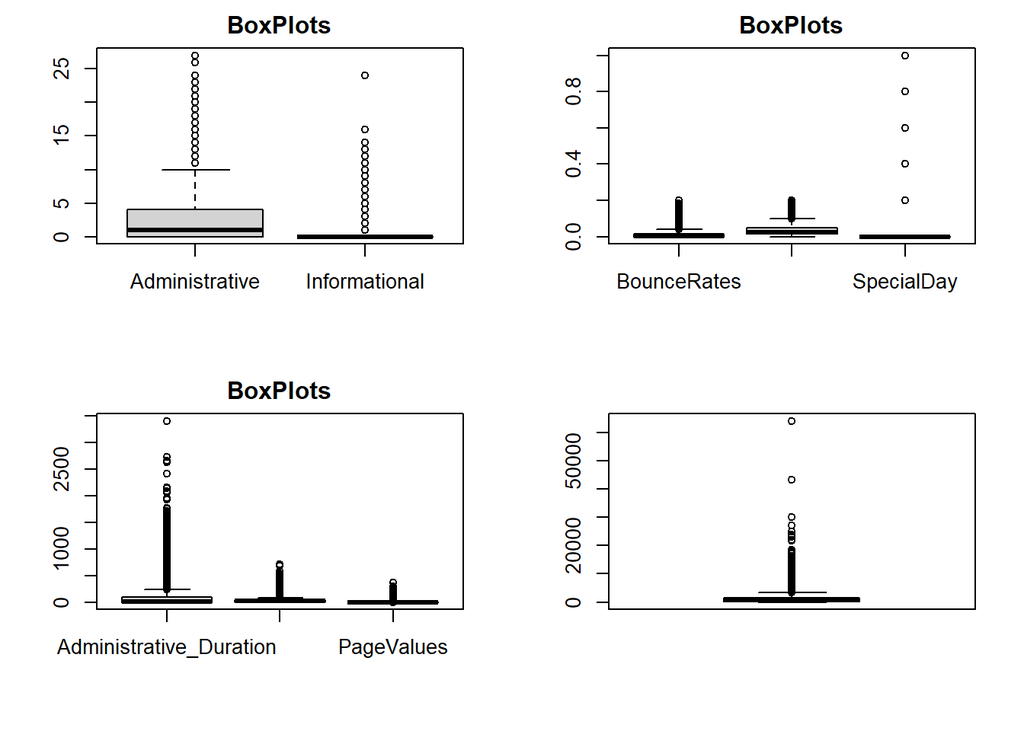

```r
par(mfrow = c(2,2), mar = c(5,4,2,2))

# Finding all columns that are numerical/not strings & sub-setting to new data frame
df_num <- df[, !sapply(df, is.character)]
df_num1 <- subset(df_num,select = c(1,3))
boxplot(df_num1, main='BoxPlots')
df_num2 <- subset(df_num,select = c(7,8,10))
boxplot(df_num2, main='BoxPlots')
df_num3 <- subset(df_num,select = c(2,5,9))
boxplot(df_num3, main='BoxPlots')
boxplot(ProductRelated_Duration)
```

The outliers will not be removed because they represent the real world, and can provide some insights as to why they occurred.

## EXploratory Data Analysis

### Univariate Analysis

#### Categorical variables

```r
categorical_columns = df[(c(11:18))]
head(categorical_columns)
```

```
##   Month OperatingSystems Browser Region TrafficType       VisitorType Weekend
## 1   Feb                1       1      1           1 Returning_Visitor   FALSE
## 2   Feb                2       2      1           2 Returning_Visitor   FALSE
## 3   Feb                4       1      9           3 Returning_Visitor   FALSE
## 4   Feb                3       2      2           4 Returning_Visitor   FALSE
## 5   Feb                3       3      1           4 Returning_Visitor    TRUE
## 6   Feb                2       2      1           3 Returning_Visitor   FALSE
##   Revenue
## 1   FALSE
## 2   FALSE
## 3   FALSE
## 4   FALSE
## 5   FALSE
## 6   FALSE
```

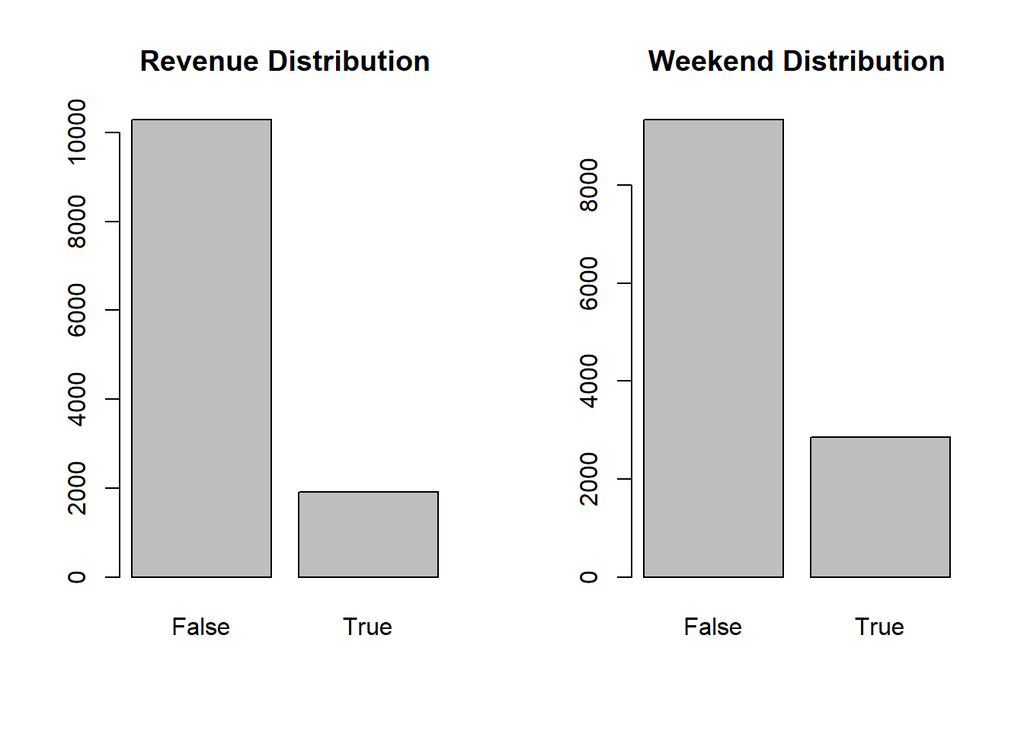

```r
par(mfrow=c(1, 2))

Revenue.distribution <- table(Revenue)
label <- c("False","True")
barplot(Revenue.distribution,names.arg = label,main = "Revenue Distribution")

Weekend.distribution <- table(Weekend)
label <- c("False","True")
barplot(Weekend.distribution,names.arg = label,main = "Weekend Distribution")
```

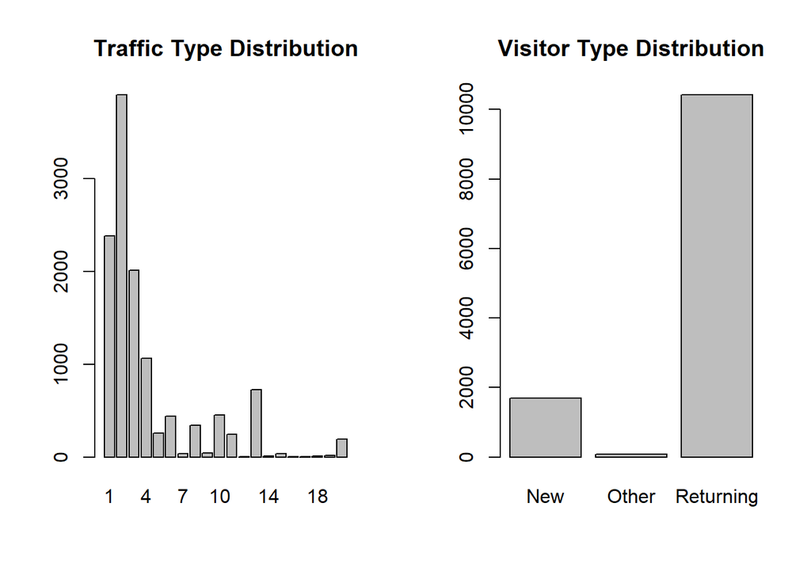

```r
TrafficType.distribution <- table(TrafficType)
barplot(TrafficType.distribution,main = "Traffic Type Distribution")

VisitorType.distribution <- table(VisitorType)
label <- c("New","Other","Returning")
barplot(VisitorType.distribution,names.arg = label,main = "Visitor Type Distribution")
```

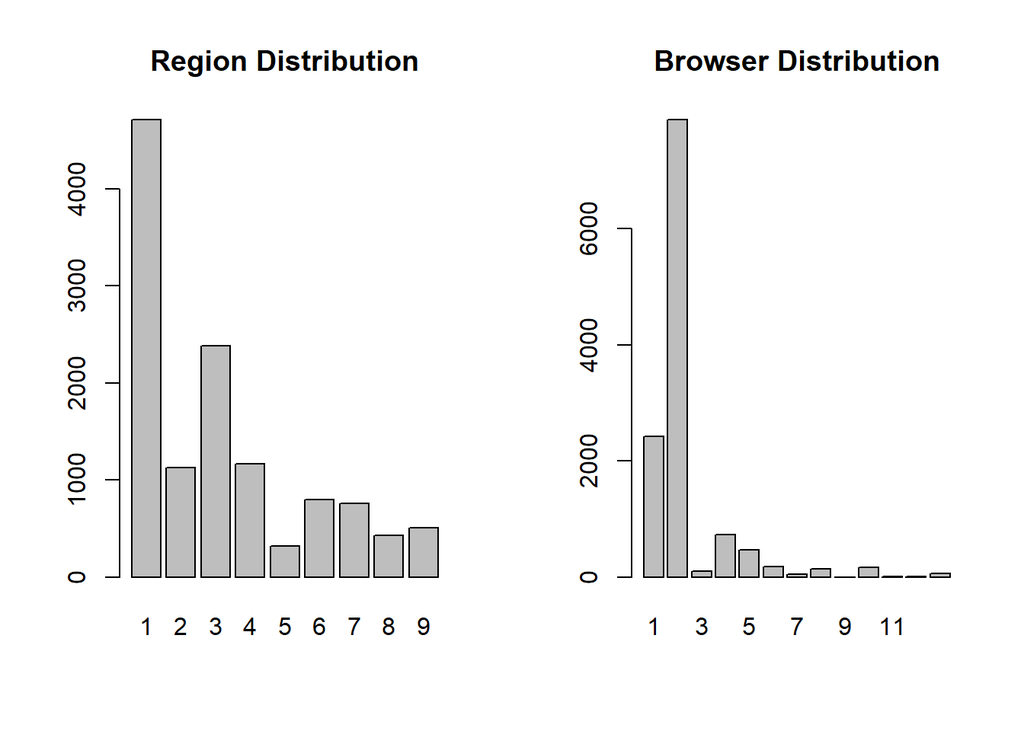

```r
Region.distribution <- table(Region)
barplot(Region.distribution,main = "Region Distribution")

Browser.distribution <- table(Browser)
barplot(Browser.distribution,main = "Browser Distribution")
```

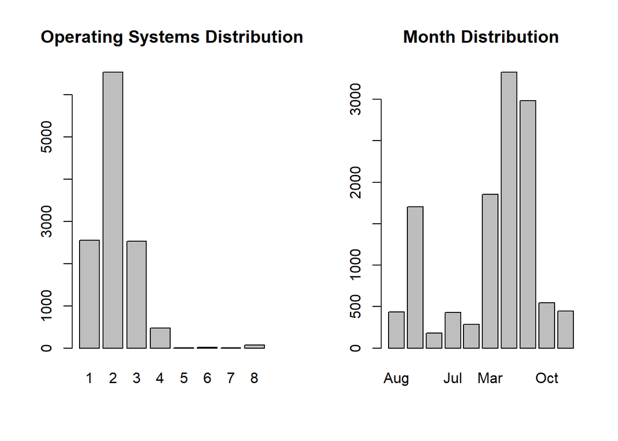

```r
OperatingSystems.distribution <- table(OperatingSystems)
barplot(OperatingSystems.distribution,main = "Operating Systems Distribution")

Month.distribution <- table(Month)
barplot(Month.distribution,main = "Month Distribution")
```

#### Numerical Variables

```r
numerical_columns = df[(c(1:10))]
head(numerical_columns)
```

```
##   Administrative Administrative_Duration Informational Informational_Duration
## 1              0                       0             0                      0
## 2              0                       0             0                      0
## 3              0                      -1             0                     -1
## 4              0                       0             0                      0
## 5              0                       0             0                      0
## 6              0                       0             0                      0
##   ProductRelated ProductRelated_Duration BounceRates ExitRates PageValues
## 1              1                0.000000  0.20000000 0.2000000          0
## 2              2               64.000000  0.00000000 0.1000000          0
## 3              1               -1.000000  0.20000000 0.2000000          0
## 4              2                2.666667  0.05000000 0.1400000          0
## 5             10              627.500000  0.02000000 0.0500000          0
## 6             19              154.216667  0.01578947 0.0245614          0
##   SpecialDay
## 1          0
## 2          0
## 3          0
## 4          0
## 5          0
## 6          0
```

##### Histogram plots

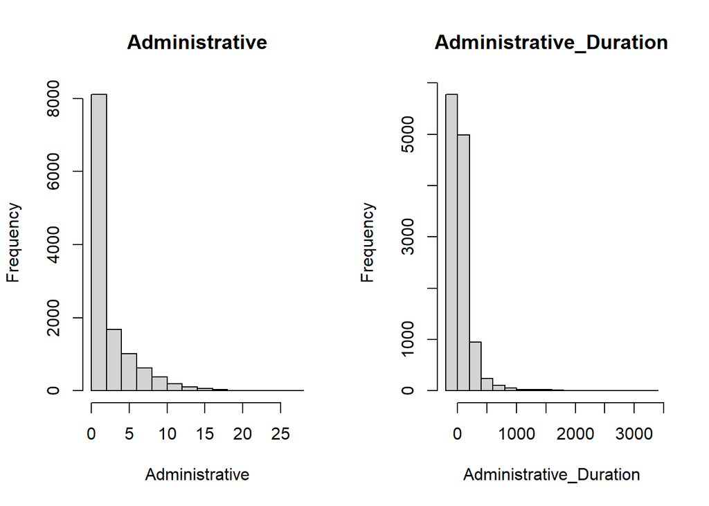

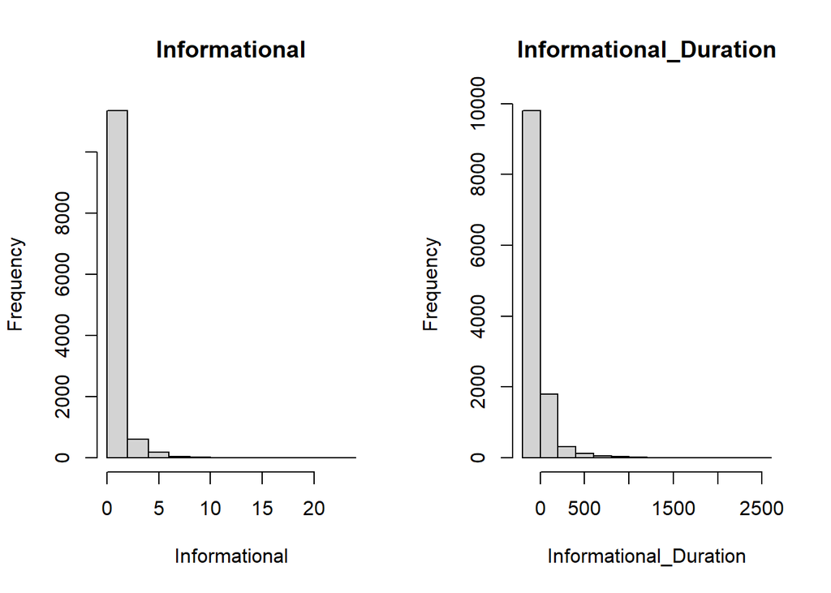

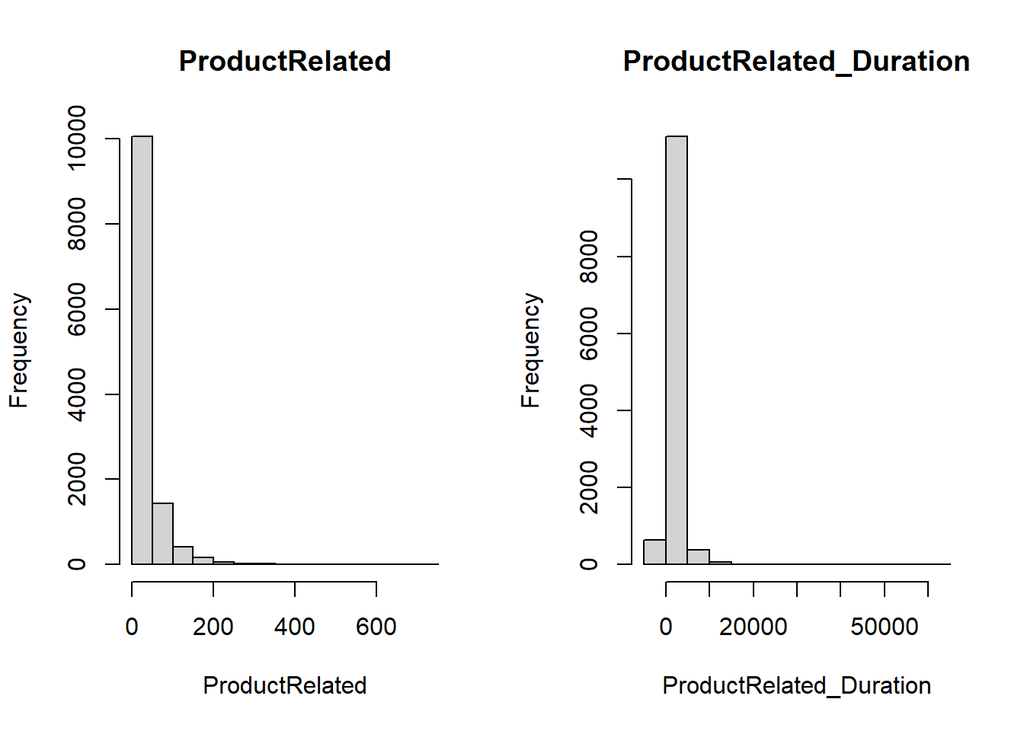

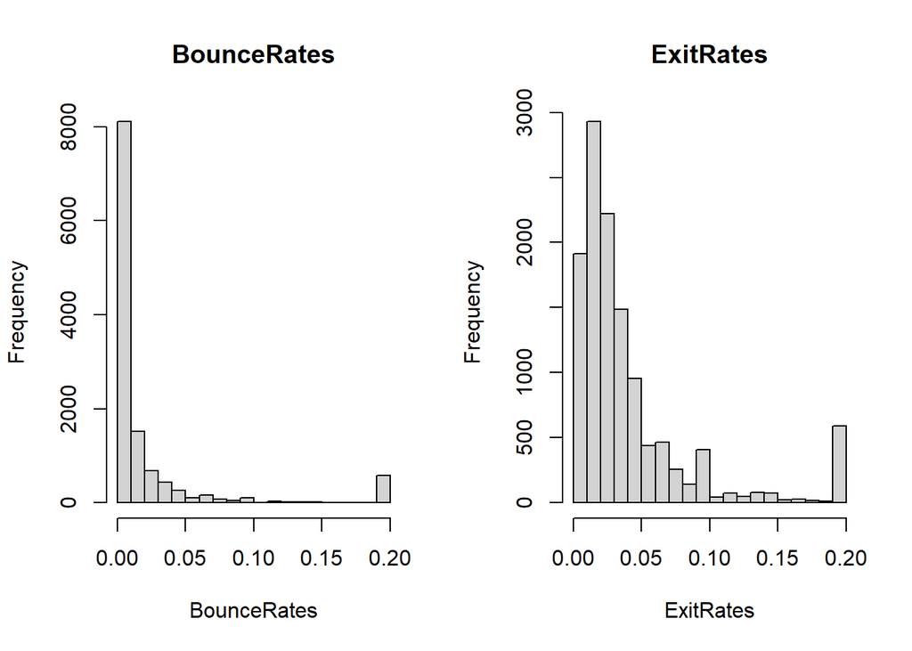

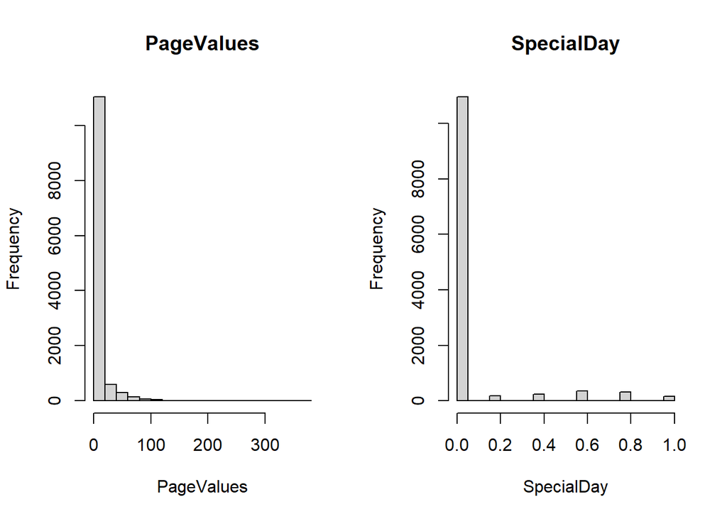

```r
par(mfrow=c(1, 2))


for (i in 1:10) {
  hist(numerical_columns[, i], main = names(numerical_columns)[i], xlab = names(numerical_columns)[i])
}
```

```r
colnames(df)
```

```
##  [1] "Administrative"          "Administrative_Duration"
##  [3] "Informational"           "Informational_Duration"
##  [5] "ProductRelated"          "ProductRelated_Duration"
##  [7] "BounceRates"             "ExitRates"
##  [9] "PageValues"              "SpecialDay"
## [11] "Month"                   "OperatingSystems"
## [13] "Browser"                 "Region"
## [15] "TrafficType"             "VisitorType"
## [17] "Weekend"                 "Revenue"
```

##### Measures of central Tendencies (mean ,median,mode)

#### **Mean**

```r
library(dplyr)
numerical_columns%>% summarise_if(is.numeric, mean)
```

```
##   Administrative Administrative_Duration Informational Informational_Duration
## 1       2.340028                81.68214     0.5088122               34.83734
##   ProductRelated ProductRelated_Duration BounceRates  ExitRates PageValues
## 1       32.05845                1207.508  0.02044674 0.04149678     5.9525
##   SpecialDay
## 1 0.06197229
```

```r
numerical_columns%>% summarise_if(is.numeric, median)
```

```
##   Administrative Administrative_Duration Informational Informational_Duration
## 1              1                       9             0                      0
##   ProductRelated ProductRelated_Duration BounceRates ExitRates PageValues
## 1             18                609.5417 0.002930403     0.025          0
##   SpecialDay
## 1          0
```

```r
getmode = function(v){
   uniqv <- unique(v)
   uniqv[which.max(tabulate(match(v, uniqv)))]
}
```

```r
numerical_columns%>% summarise_if(is.numeric,getmode)
```

```
##   Administrative Administrative_Duration Informational Informational_Duration
## 1              0                       0             0                      0
##   ProductRelated ProductRelated_Duration BounceRates ExitRates PageValues
## 1              1                       0           0       0.2          0
##   SpecialDay
## 1          0
```

```r
getmode(Month)
```

```
## [1] "May"
```

```r
getmode(Weekend)
```

```
## [1] FALSE
```

```r
getmode(Revenue)
```

```
## [1] FALSE
```

```r
library(psych)
```

```r
describe(numerical_columns)
```

```
##                         vars     n    mean      sd median trimmed    mad min
## Administrative             1 12199    2.34    3.33   1.00    1.66   1.48   0
## Administrative_Duration    2 12199   81.68  177.53   9.00   42.87  13.34  -1
## Informational              3 12199    0.51    1.28   0.00    0.18   0.00   0
## Informational_Duration     4 12199   34.84  141.46   0.00    3.73   0.00  -1
## ProductRelated             5 12199   32.06   44.60  18.00   23.06  19.27   0
## ProductRelated_Duration    6 12199 1207.51 1919.93 609.54  832.36 745.12  -1
## BounceRates                7 12199    0.02    0.05   0.00    0.01   0.00   0
## ExitRates                  8 12199    0.04    0.05   0.03    0.03   0.02   0
## PageValues                 9 12199    5.95   18.66   0.00    1.33   0.00   0
## SpecialDay                10 12199    0.06    0.20   0.00    0.00   0.00   0
##                              max    range skew kurtosis    se
## Administrative             27.00    27.00 1.95     4.63  0.03
## Administrative_Duration  3398.75  3399.75 5.59    50.09  1.61
## Informational              24.00    24.00 4.01    26.64  0.01
## Informational_Duration   2549.38  2550.38 7.54    75.45  1.28
## ProductRelated            705.00   705.00 4.33    31.04  0.40
## ProductRelated_Duration 63973.52 63974.52 7.25   136.57 17.38
## BounceRates                 0.20     0.20 3.15     9.25  0.00
## ExitRates                   0.20     0.20 2.23     4.62  0.00
## PageValues                361.76   361.76 6.35    64.93  0.17
## SpecialDay                  1.00     1.00 3.28     9.78  0.00
```

All our numerical columns are positively skewed and are Leptokurtic. This shows that our data is not normally distributed hence we need to normalize during creation of our models.

### Bivariate Analysis

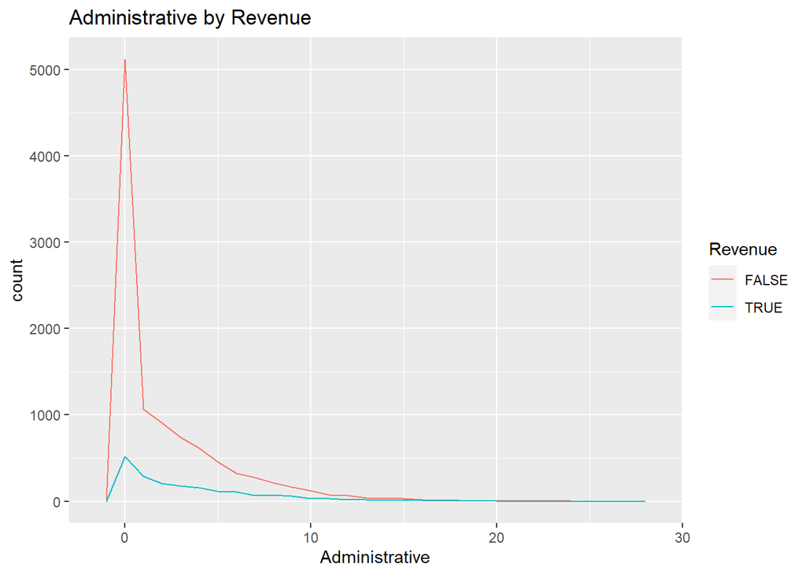

```r
library(ggplot2)
# Administrative by Revenue
ggplot(df, aes(x = Administrative, fill = Revenue, color = Revenue)) +
geom_freqpoly(binwidth = 1) +
labs(title = "Administrative by Revenue")
```

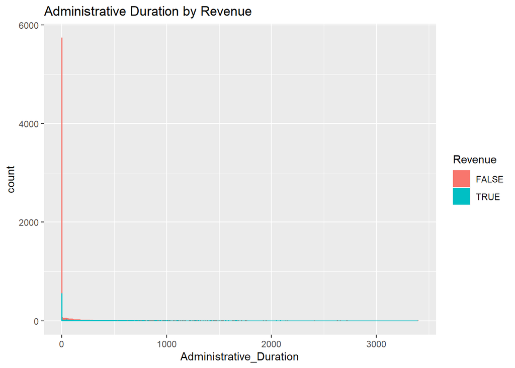

```r
ggplot(df, aes(x = Administrative_Duration, fill = Revenue, color = Revenue)) +
geom_histogram(binwidth = 1) +
labs(title = "Administrative Duration by Revenue")
```

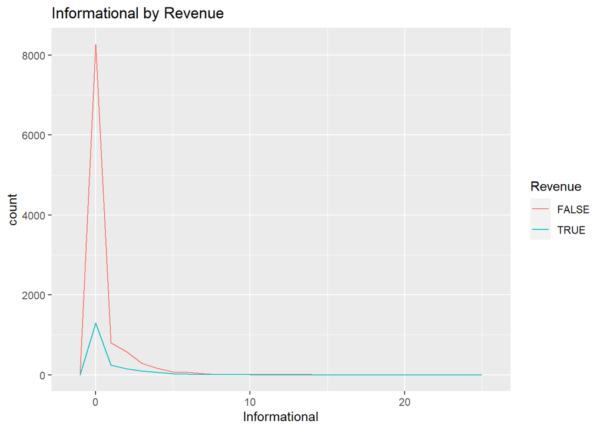

```r
ggplot(df, aes(x = Informational, fill = Revenue, color = Revenue)) +
geom_freqpoly(binwidth = 1) +
labs(title = "Informational by Revenue")
```

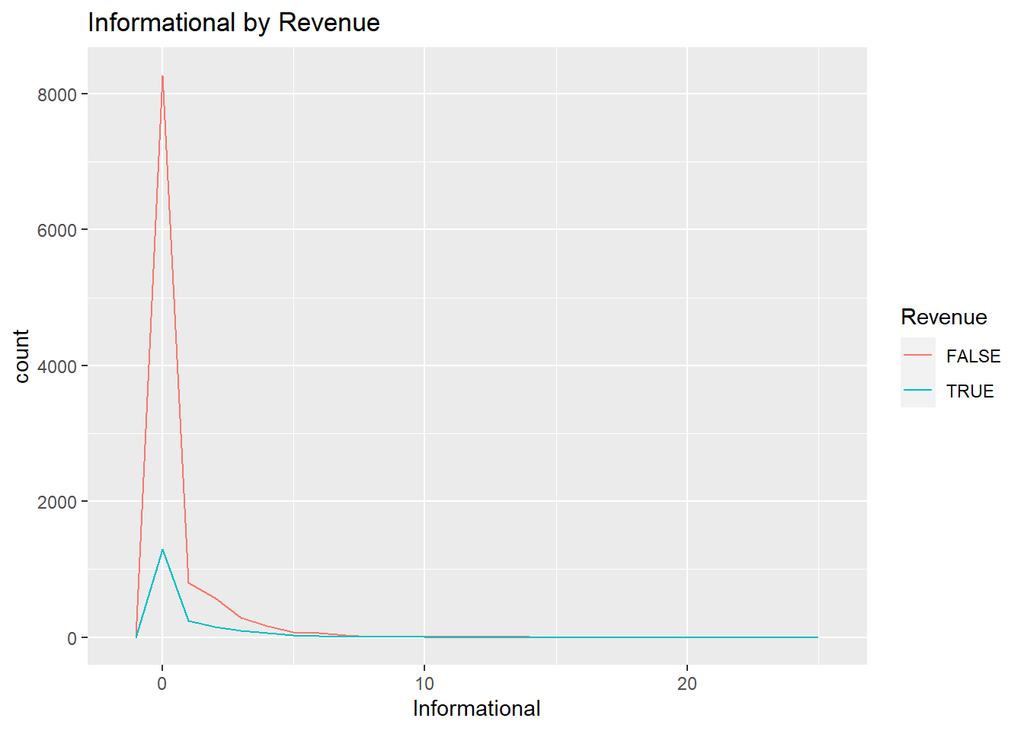

```r
ggplot(df, aes(x = Informational, fill = Revenue, color = Revenue)) +
geom_freqpoly(binwidth = 1) +
labs(title = "Informational by Revenue")
```

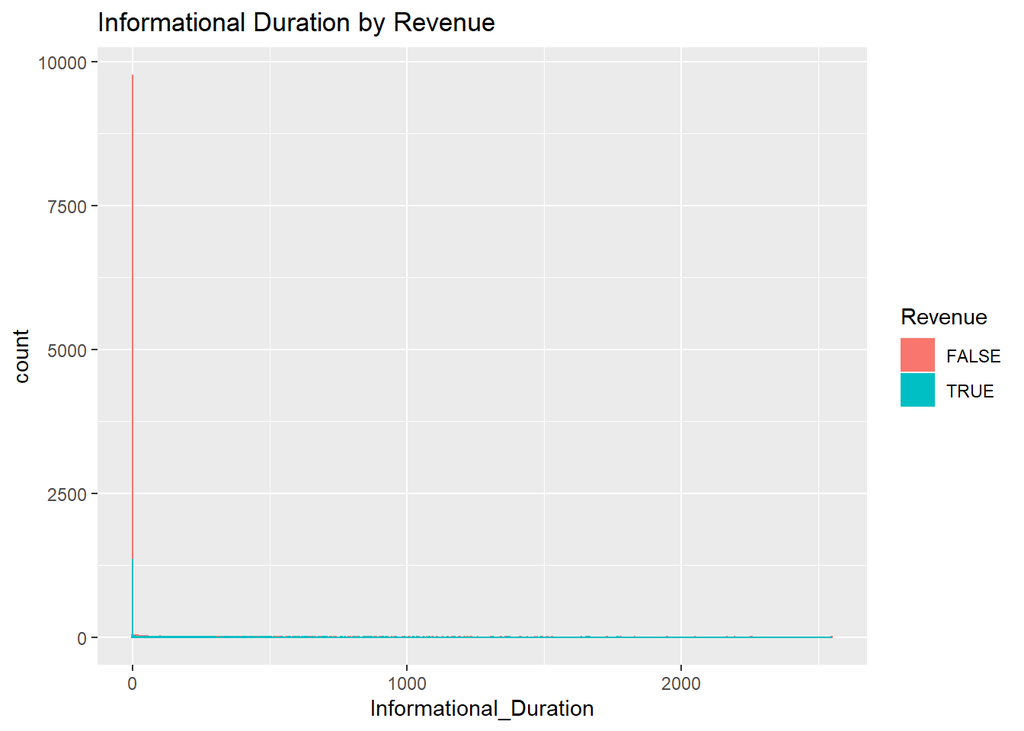

```r
ggplot(df, aes(x = Informational_Duration, fill = Revenue, color = Revenue)) +
geom_histogram(binwidth = 1) +
labs(title = "Informational Duration by Revenue")
```

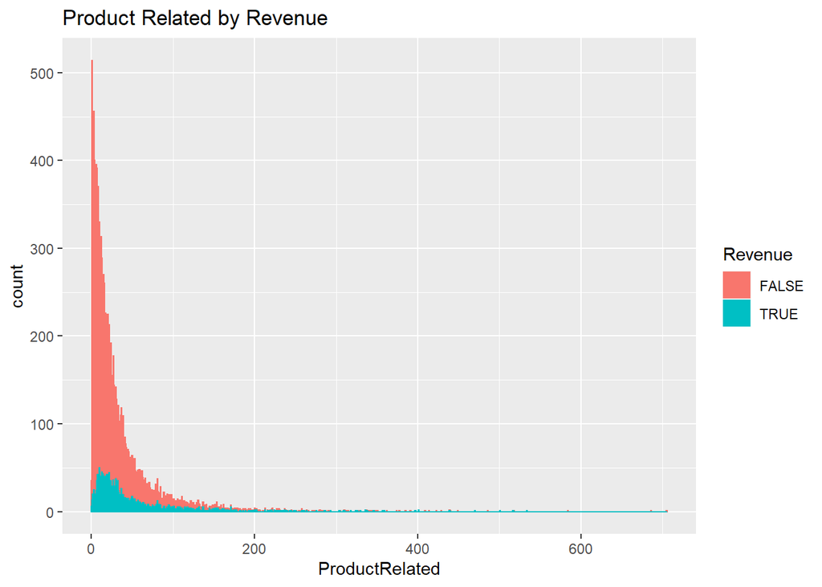

```r
ggplot(df, aes(x = ProductRelated, fill = Revenue, color = Revenue)) +
geom_histogram(binwidth = 1) +
labs(title = "Product Related by Revenue")
```

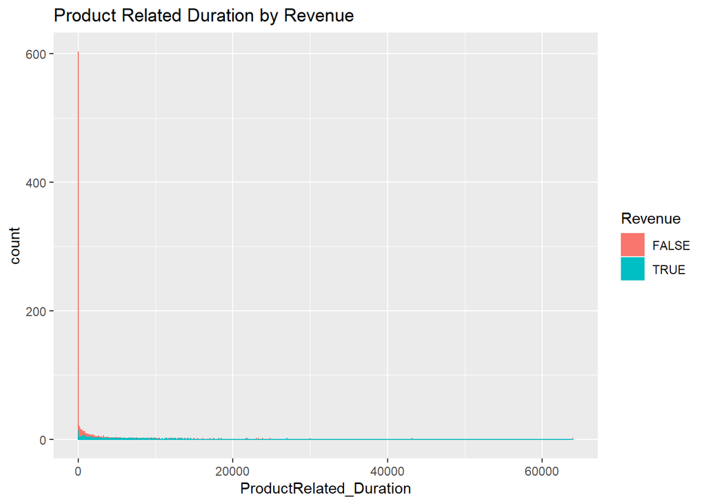

```r
ggplot(df, aes(x = ProductRelated_Duration, fill = Revenue, color = Revenue)) +
geom_histogram(binwidth = 1) +
labs(title = "Product Related Duration by Revenue")
```

```r
library(ggplot2)
```

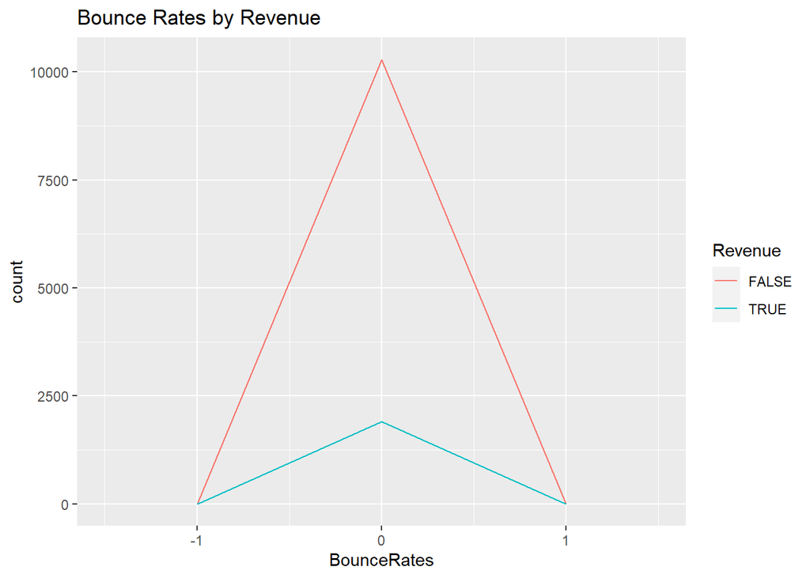

```r
ggplot(df, aes(x = BounceRates, fill = Revenue, color = Revenue)) +
geom_freqpoly(binwidth = 1) +
labs(title = "Bounce Rates by Revenue")
```

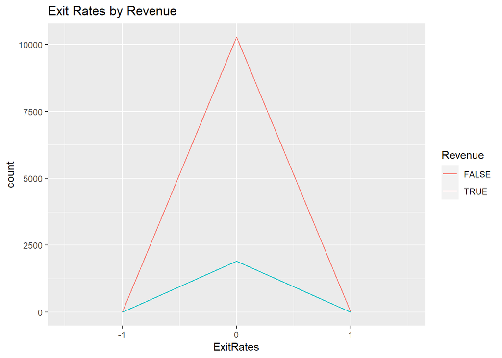

```r
ggplot(df, aes(x = ExitRates, fill = Revenue, color = Revenue)) +
geom_freqpoly(binwidth = 1) +
labs(title = "Exit Rates by Revenue")
```

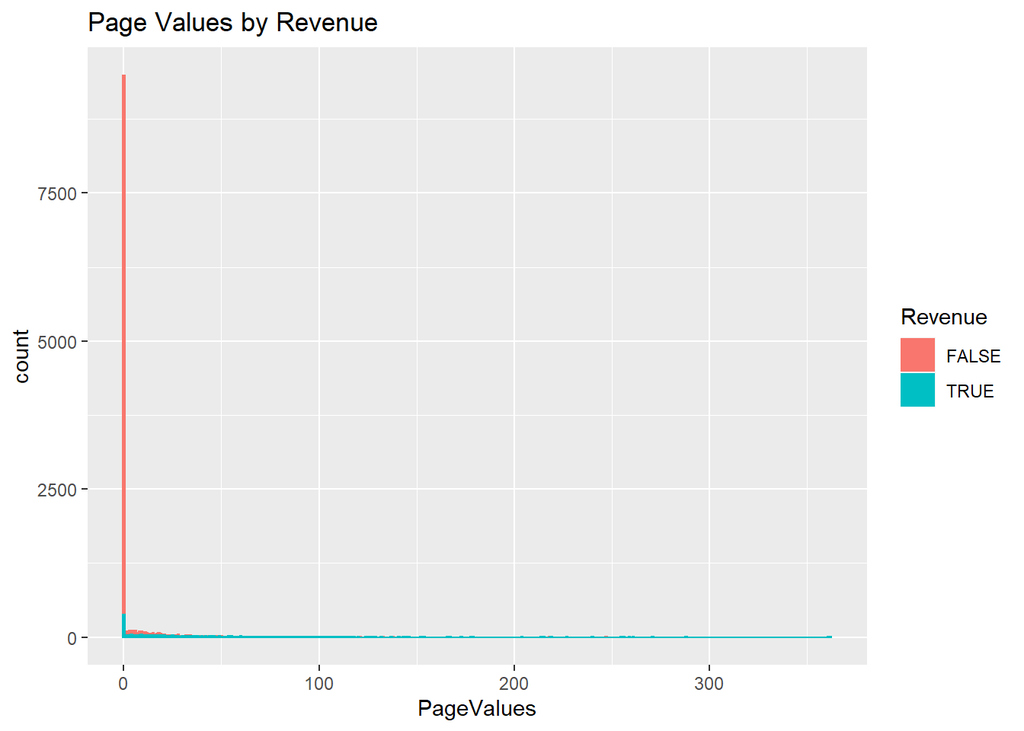

```r
ggplot(df, aes(x = PageValues, fill = Revenue, color = Revenue)) +
geom_histogram(binwidth = 1) +
labs(title = "Page Values by Revenue")
```

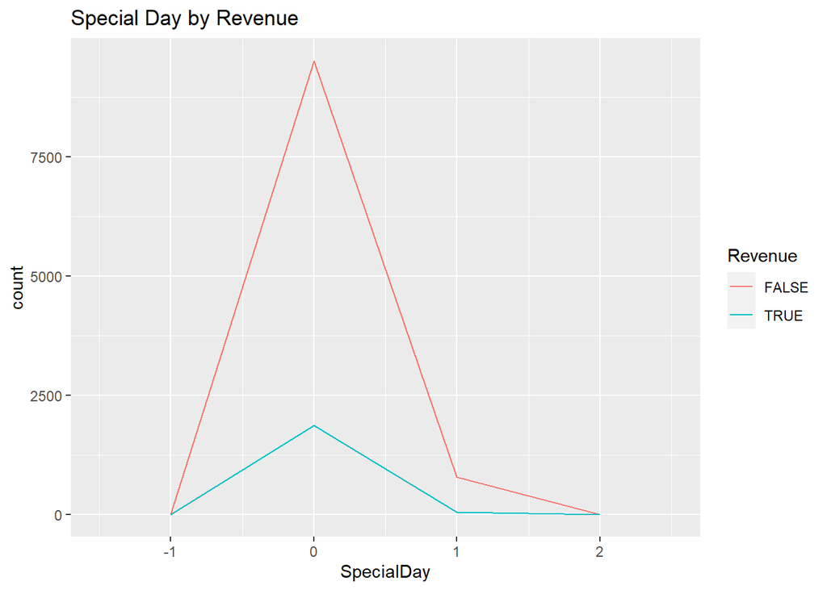

```r
ggplot(df, aes(x = SpecialDay, fill = Revenue, color = Revenue)) +
geom_freqpoly(binwidth = 1) +
labs(title = "Special Day by Revenue")
```

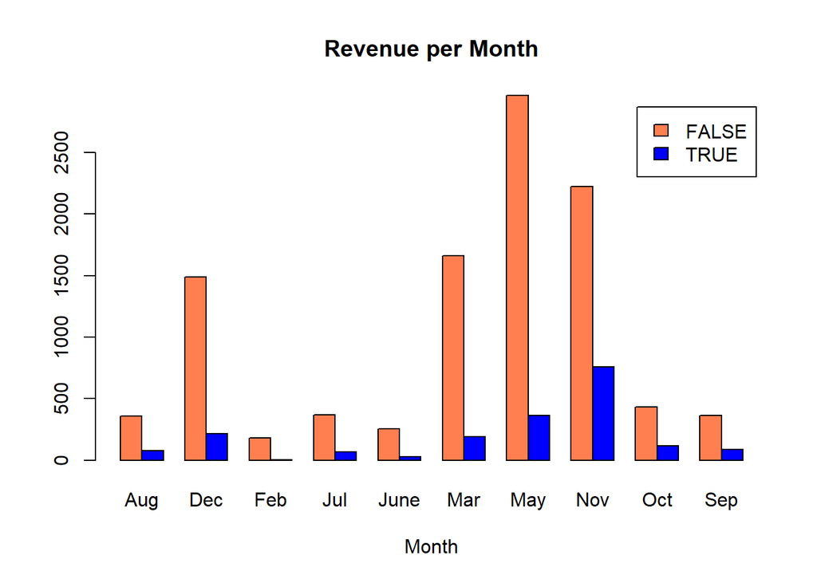

```r
rev_month <- table(Revenue,Month)
barplot(rev_month, main = "Revenue per Month", col = c("coral", "blue"), beside = TRUE,
        legend = rownames(rev_month), xlab = "Month")
```

November returns the highest number of revenues while February returns the lowest.

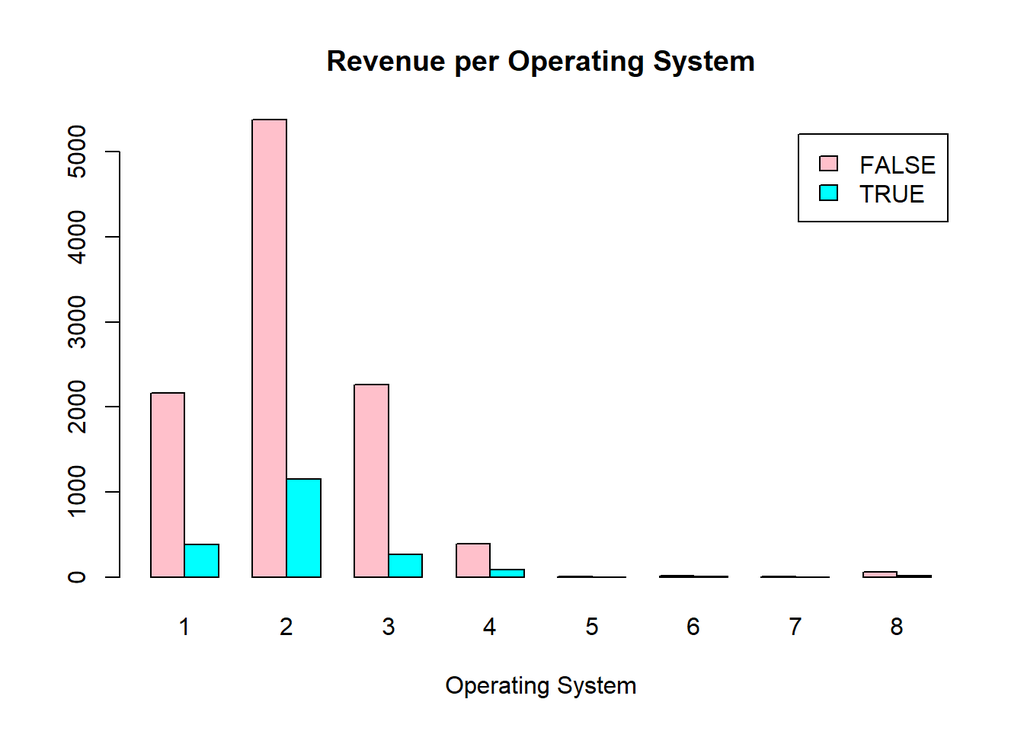

```r
rev_os <- table(Revenue,OperatingSystems)
barplot(rev_os, main = "Revenue per Operating System", col = c("pink", "cyan"), beside = TRUE,
        legend = rownames(rev_os), xlab = "Operating System")
```

Operating System 2 returns the highest number of revenue while OS 5, 6, and 7 return the lowest.

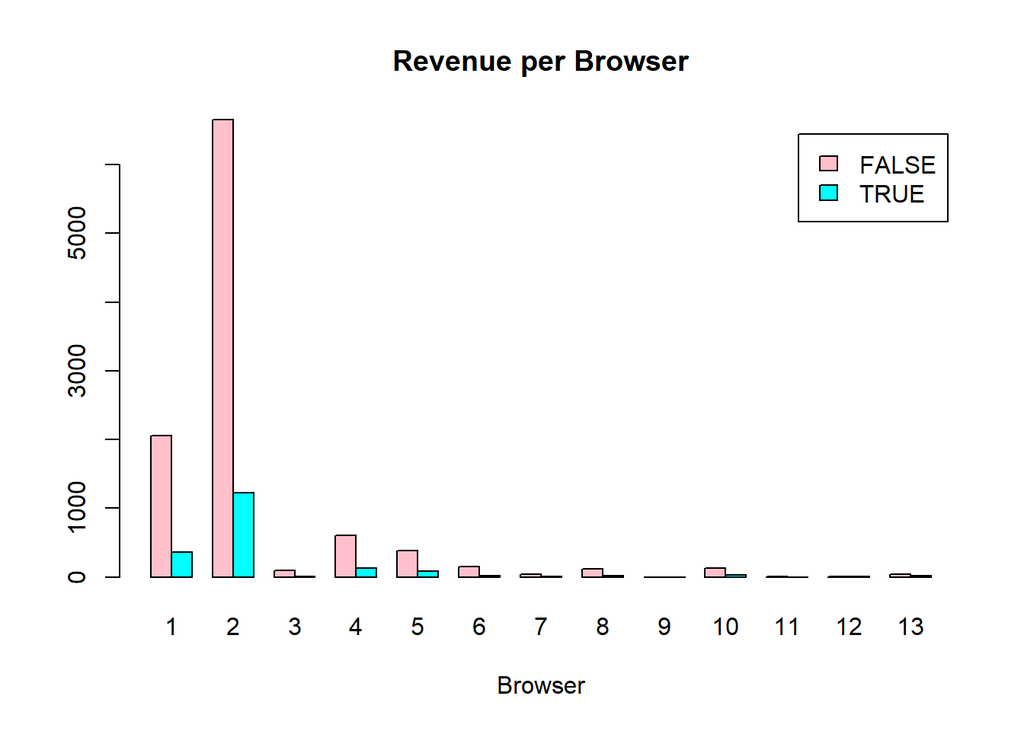

```r
rev_browser <- table(Revenue,Browser)
barplot(rev_browser, main = "Revenue per Browser", col = c("pink", "cyan"), beside = TRUE,
        legend = rownames(rev_browser), xlab = "Browser")
```

Browser 2 returns the highest number of revenue while 3, 7, 9, 11, and 12 return the lowest.

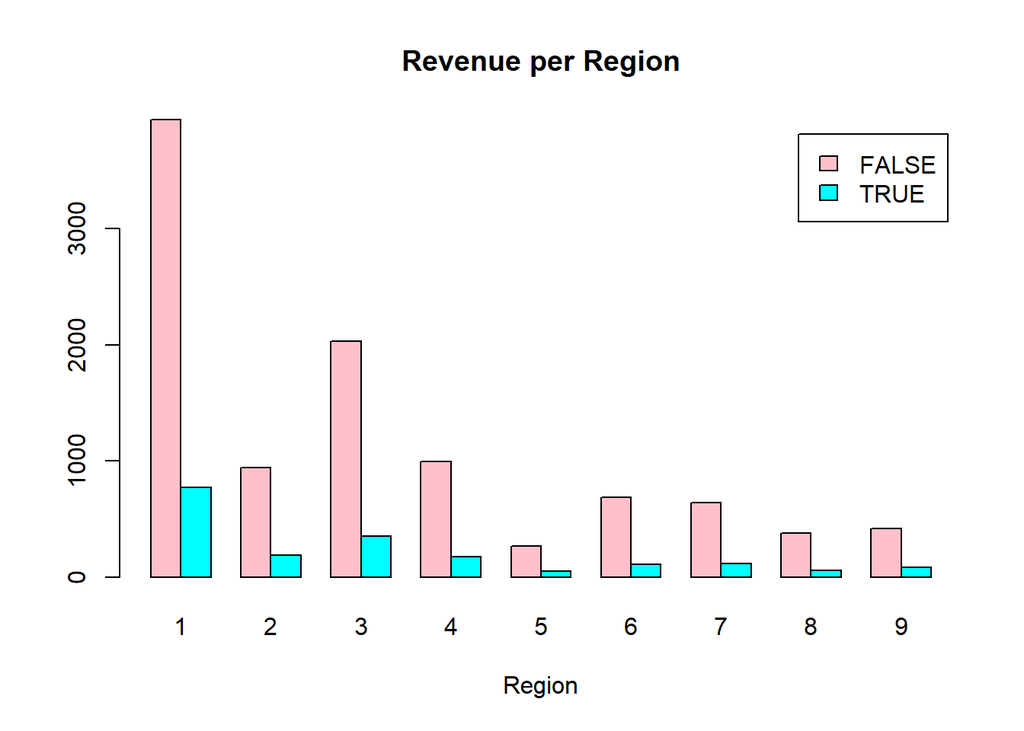

```r
rev_region <- table(Revenue,Region)
barplot(rev_region, main = "Revenue per Region", col = c("pink", "cyan"), beside = TRUE,
        legend = rownames(rev_region), xlab = "Region")
```

Region 1 returns the highest number of revenue, Region 5 returns the lowest.

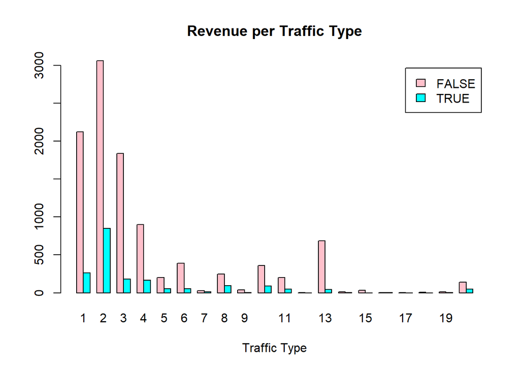

```r
rev_traffic <- table(Revenue,TrafficType)
barplot(rev_traffic, main = "Revenue per Traffic Type", col = c("pink", "cyan"), beside = TRUE,
        legend = rownames(rev_traffic), xlab = "Traffic Type")
```

Traffic 2 has the highest number of revenues, 12, 14, 16, 17, and 18 return the lowest.

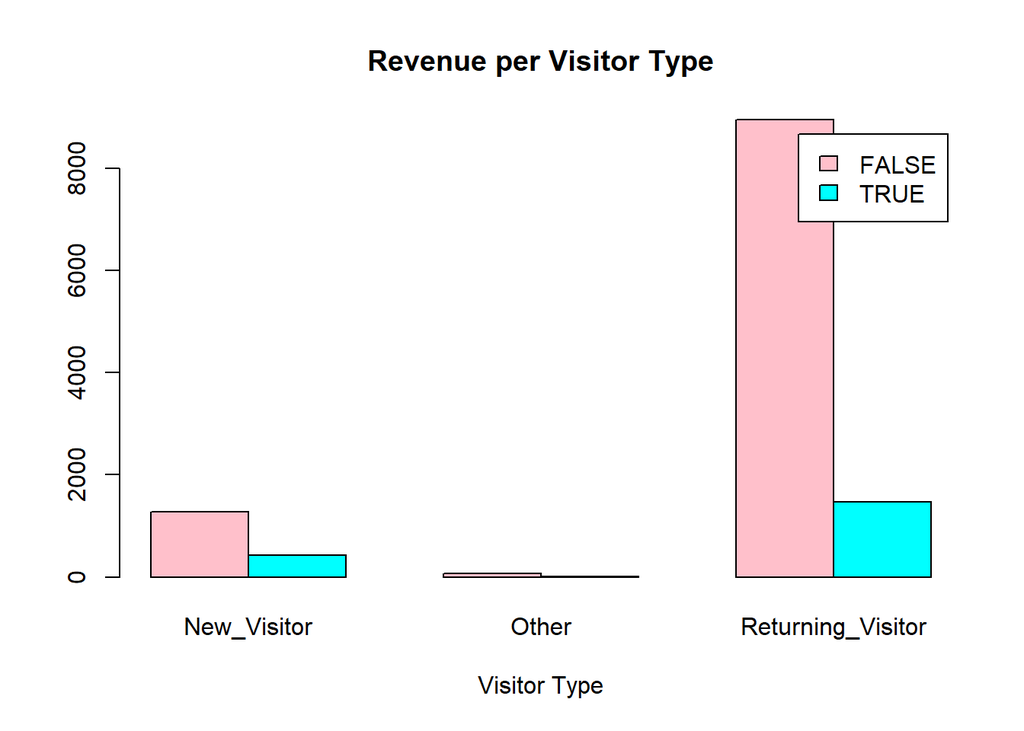

```r
rev_visitor <- table(Revenue,VisitorType)
barplot(rev_visitor, main = "Revenue per Visitor Type", col = c("pink", "cyan"), beside = TRUE,
        legend = rownames(rev_visitor), xlab = "Visitor Type")
```

Returning visitors generated more revenue.

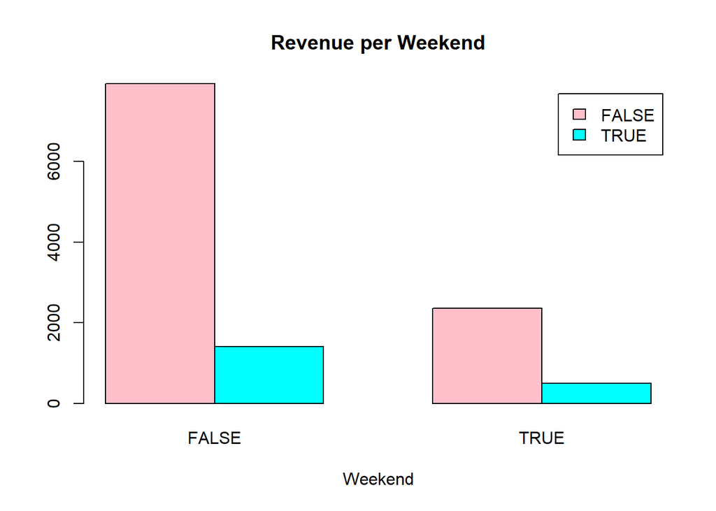

```r
rev_weekend <- table(Revenue, Weekend)
barplot(rev_weekend, main = "Revenue per Weekend", col = c("pink", "cyan"), beside = TRUE,
        legend = rownames(rev_weekend), xlab = "Weekend")
```

As expected, more revenue was generated during the weekdays than the weekends. This is to be expected since there are way more records of weekdays than of weekends.

Now to find the correlations between the numerical variables.

```r
# using a heat map to visualize variable correlations
library(corrplot)
corr_df <- cor(numerical_columns,method = "pearson")
```

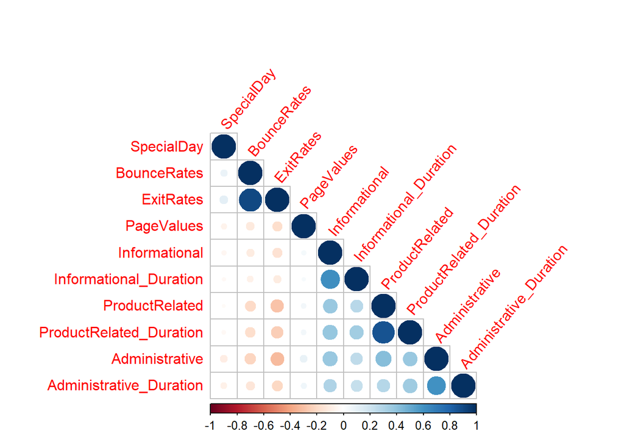

```r
corrplot(corr_df, type = "lower", order = "hclust", tl.col = "red", tl.srt = 50)
```

As suspected, BounceRates is very highly correlated to ExitRates, Administrative is correlated with Administrative_Duration, Informational is highly correlated to Informational_Duration, and ProductRelated is highly correlated with ProductRated_Duration. Therefore, we will have to drop one variable of each of the highly correlated pairs to reduce dimensionality and redundancy.

```r
# dropping the highly correlated columns
to_drop <- c("Administrative_Duration", "Informational_Duration", "ProductRelated_Duration", "ExitRates")

df <- df[, !names(df) %in% to_drop]
head(df)
```

```
##   Administrative Informational ProductRelated BounceRates PageValues SpecialDay
## 1              0             0              1  0.20000000          0          0
## 2              0             0              2  0.00000000          0          0
## 3              0             0              1  0.20000000          0          0
## 4              0             0              2  0.05000000          0          0
## 5              0             0             10  0.02000000          0          0
## 6              0             0             19  0.01578947          0          0
##   Month OperatingSystems Browser Region TrafficType       VisitorType Weekend
## 1   Feb                1       1      1           1 Returning_Visitor   FALSE
## 2   Feb                2       2      1           2 Returning_Visitor   FALSE
## 3   Feb                4       1      9           3 Returning_Visitor   FALSE
## 4   Feb                3       2      2           4 Returning_Visitor   FALSE
## 5   Feb                3       3      1           4 Returning_Visitor    TRUE
## 6   Feb                2       2      1           3 Returning_Visitor   FALSE
##   Revenue
## 1   FALSE
## 2   FALSE
## 3   FALSE
## 4   FALSE
## 5   FALSE
## 6   FALSE
```

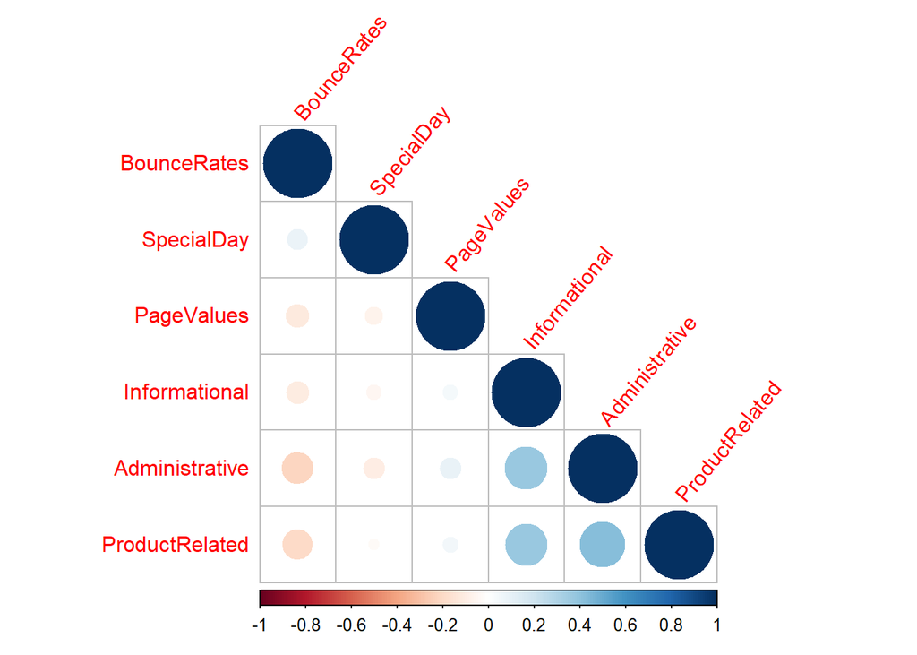

```r
new_corr_df <- cor(df[1:6])
corrplot(new_corr_df, type = "lower", order = "hclust", tl.col = "red", tl.srt = 50)
```

As we can see, removing the highly correlated variables reduced multicollinearity in our dataset. It also made it easier to work with. We can now move on to modelling.

# IMPLEMENTING THE SOLUTION

```r
library(CatEncoders)
df$Weekend <- as.character(df$Weekend)
df$Revenue <- as.character(df$Revenue)
```

```r
# Label encode the categorical columns
for (i in c(7,12,13,14)) {

  encode = LabelEncoder.fit(df[,i])
  df[,i] = transform(encode, df[,i])
}
```

```r
head(df)
```

```
##   Administrative Informational ProductRelated BounceRates PageValues SpecialDay
## 1              0             0              1  0.20000000          0          0
## 2              0             0              2  0.00000000          0          0
## 3              0             0              1  0.20000000          0          0
## 4              0             0              2  0.05000000          0          0
## 5              0             0             10  0.02000000          0          0
## 6              0             0             19  0.01578947          0          0
##   Month OperatingSystems Browser Region TrafficType VisitorType Weekend Revenue
## 1     3                1       1      1           1           3       1       1
## 2     3                2       2      1           2           3       1       1
## 3     3                4       1      9           3           3       1       1
## 4     3                3       2      2           4           3       1       1
## 5     3                3       3      1           4           3       2       1
## 6     3                2       2      1           3           3       1       1
```

```r
#Create a data frame without the target variable
df.new <- df[(c(1:14))]
df.new
```

[output not shown]

[output cut: 21415 more lines]

### K-MEANS CLUSTERING

#### **normalizing the data**

```r
normalize <- function(x){
  return ((x-min(x)) / (max(x)-min(x)))
}

df_normal <- normalize (df.new)
```

```r
# This step was added because finding the optimum number of clusters took sometime. therefore taking a random sample of 1000
random_df <- df_normal[sample(nrow(df_normal), size=1000), ]
head(random_df)
```

```
##       Administrative Informational ProductRelated  BounceRates PageValues
## 11660    0.000000000   0.000000000     0.08085106 2.445586e-06 0.00000000
## 7589     0.001418440   0.000000000     0.01560284 7.565012e-05 0.00000000
## 400      0.009929078   0.005673759     0.04397163 1.212342e-06 0.01690794
## 10411    0.000000000   0.000000000     0.01276596 3.152088e-05 0.00000000
## 12270    0.009929078   0.000000000     0.03404255 1.134752e-05 0.00000000
## 4878     0.000000000   0.000000000     0.14609929 4.241413e-05 0.00000000
##        SpecialDay       Month OperatingSystems     Browser      Region
## 11660 0.000000000 0.011347518      0.002836879 0.009929078 0.002836879
## 7589  0.000000000 0.001418440      0.004255319 0.002836879 0.011347518
## 400   0.000000000 0.008510638      0.002836879 0.002836879 0.009929078
## 10411 0.000000000 0.011347518      0.002836879 0.002836879 0.004255319
## 12270 0.000000000 0.002836879      0.001418440 0.001418440 0.001418440
## 4878  0.001134752 0.009929078      0.004255319 0.002836879 0.001418440
##       TrafficType VisitorType     Weekend     Revenue
## 11660 0.002836879 0.004255319 0.002836879 0.001418440
## 7589  0.001418440 0.004255319 0.001418440 0.001418440
## 400   0.002836879 0.004255319 0.001418440 0.002836879
## 10411 0.002836879 0.004255319 0.001418440 0.001418440
## 12270 0.004255319 0.004255319 0.001418440 0.001418440
## 4878  0.018439716 0.004255319 0.001418440 0.001418440
```

```r
# Loading the required libraries
library(factoextra)
library(NbClust)
library (cluster)
```

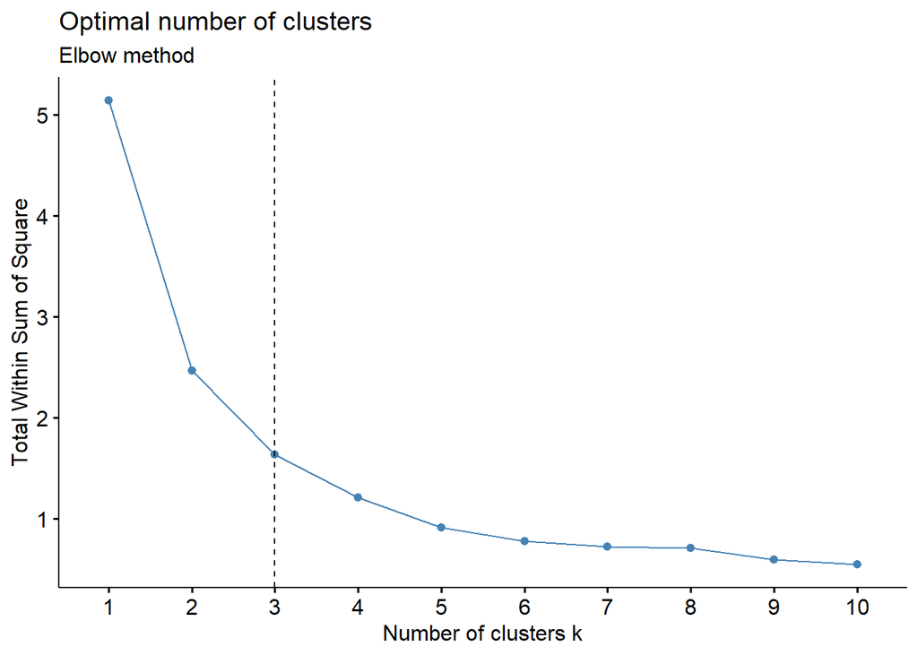

```r
# Elbow method
fviz_nbclust(random_df, kmeans, method = "wss") +
    geom_vline(xintercept = 3, linetype = 2)+
  labs(subtitle = "Elbow method")
```

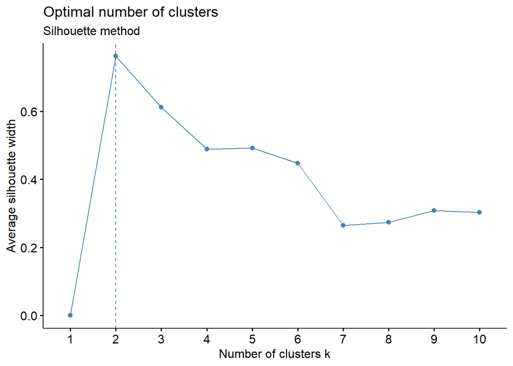

```r
# Silhouette method
fviz_nbclust(random_df, kmeans, method = "silhouette")+
  labs(subtitle = "Silhouette method")
```

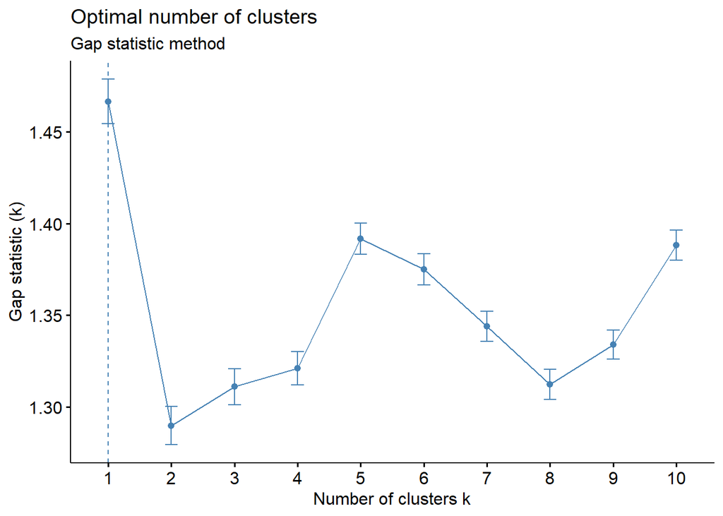

```r
# Gap statistic
# nboot = 500 to keep the function speedy.

set.seed(123)
fviz_nbclust(random_df, kmeans, nstart = 25,  method = "gap_stat", nboot = 500)+
  labs(subtitle = "Gap statistic method")
```

```r
# choosing the best number of clusters
nb<-NbClust(data = random_df, distance = "euclidean",
        min.nc = 2, max.nc = 15, method = "kmeans")
```

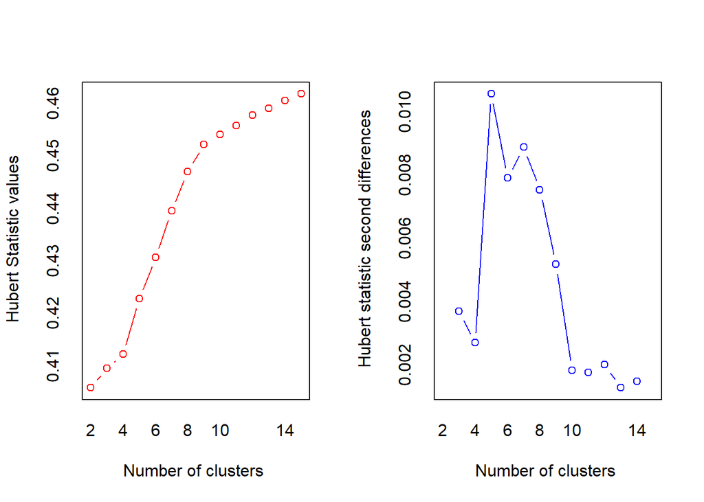

```
## *** : The Hubert index is a graphical method of determining the number of clusters.
##                 In the plot of Hubert index, we seek a significant knee that corresponds to a
##                 significant increase of the value of the measure i.e the significant peak in Hubert
##                 index second differences plot.
##
```

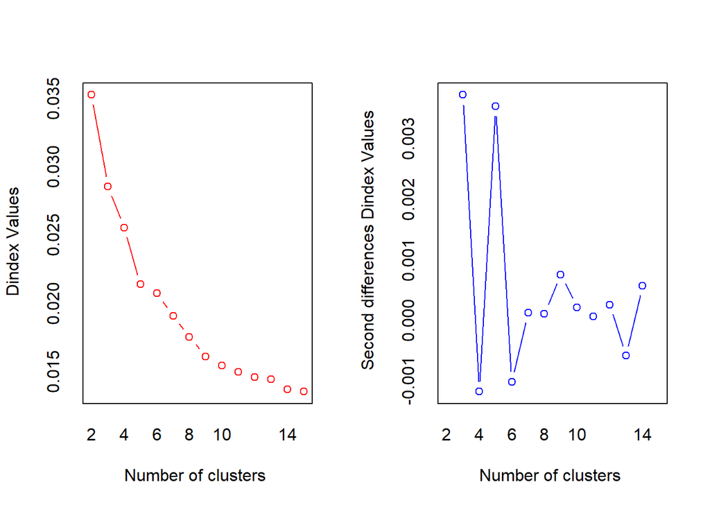

```
## *** : The D index is a graphical method of determining the number of clusters.
##                 In the plot of D index, we seek a significant knee (the significant peak in Dindex
##                 second differences plot) that corresponds to a significant increase of the value of
##                 the measure.
##
## * Among all indices:
## * 6 proposed 2 as the best number of clusters
## * 3 proposed 3 as the best number of clusters
## * 5 proposed 4 as the best number of clusters
## * 5 proposed 5 as the best number of clusters
## * 1 proposed 6 as the best number of clusters
## * 1 proposed 7 as the best number of clusters
## * 1 proposed 11 as the best number of clusters
## * 1 proposed 14 as the best number of clusters
## * 1 proposed 15 as the best number of clusters
##
##                    ***** Conclusion *****
##
## * According to the majority rule, the best number of clusters is  2
##
##
```

```
## Among all indices:
## ===================
## * 2 proposed  0 as the best number of clusters
## * 6 proposed  2 as the best number of clusters
## * 3 proposed  3 as the best number of clusters
## * 5 proposed  4 as the best number of clusters
## * 5 proposed  5 as the best number of clusters
## * 1 proposed  6 as the best number of clusters
## * 1 proposed  7 as the best number of clusters
## * 1 proposed  11 as the best number of clusters
## * 1 proposed  14 as the best number of clusters
## * 1 proposed  15 as the best number of clusters
##
## Conclusion
## =========================
## * According to the majority rule, the best number of clusters is  2 .
```

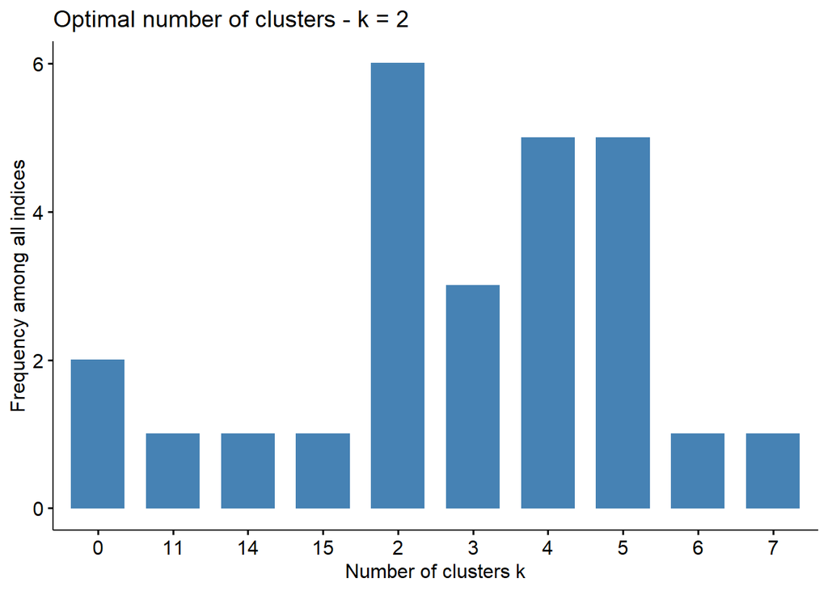

```r
fviz_nbclust(nb)
```

```r
clustering <- kmeans(df_normal,3,iter.max = 10, nstart = 25)
clustering
```

```
## K-means clustering with 3 clusters of sizes 10124, 1876, 199
##
## Cluster means:
##   Administrative Informational ProductRelated  BounceRates  PageValues
## 1    0.002542936  0.0004776236     0.02441218 3.309049e-05 0.007711976
## 2    0.006645345  0.0017246594     0.12365377 9.229680e-06 0.012392196
## 3    0.011454435  0.0036850921     0.37990663 7.427024e-06 0.008419860
##     SpecialDay       Month OperatingSystems     Browser      Region TrafficType
## 1 9.036879e-05 0.008651866      0.003005148 0.003359197 0.004520121 0.005877054
## 2 8.014638e-05 0.009160883      0.003050099 0.003265587 0.004293124 0.005322929
## 3 3.563919e-05 0.009800777      0.003079226 0.003364339 0.003756371 0.005124915
##   VisitorType     Weekend     Revenue
## 1 0.003792967 0.001747410 0.001610386
## 2 0.004131319 0.001766245 0.001773806
## 3 0.004233936 0.001760576 0.001903133
```

[output cut: 1889 more lines]

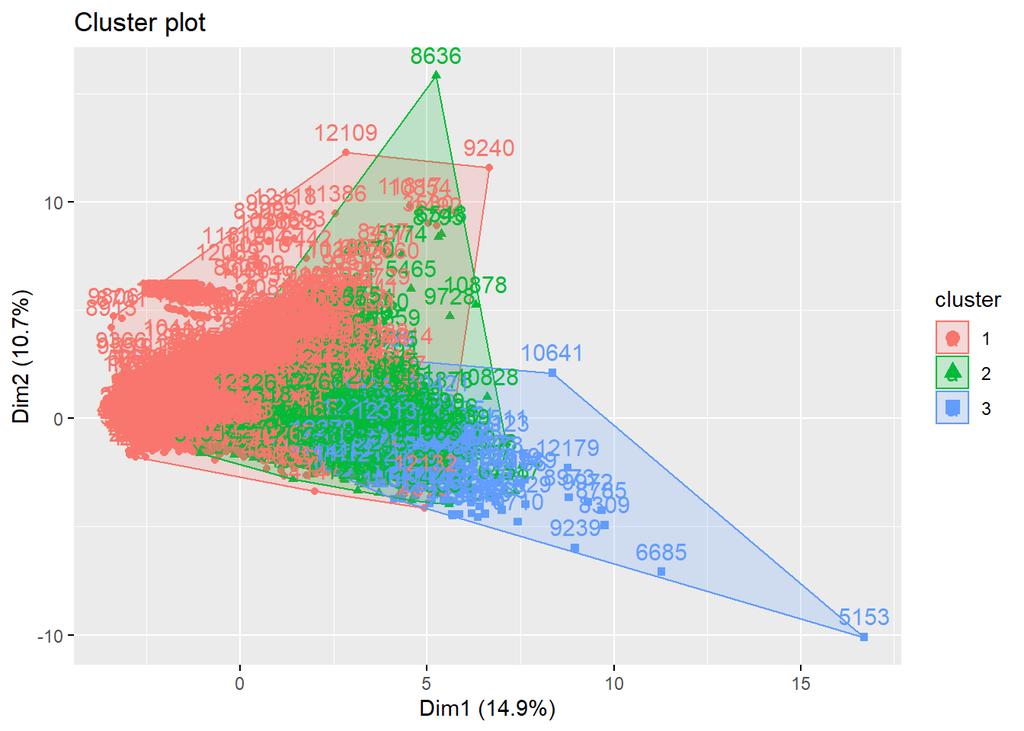

```r
#plot results of final k-means model
fviz_cluster(clustering, data = df.new)
```